# WTA_distribution

Do Won Kim

2024-03-13

# 1 Data Preparation

- `w1_users`: Wave 1 responses of users who took wave 2 survey so far (247 obs)
- `w2_users`: These same respondents’ wave 2 responses

Based on the above data frames, I made a merged dataset `wta_df`!

```r
library(tidyverse)
library(DT)
library(haven)
library(readr)


# load raw data
df_w1 <- readRDS("~/Downloads/2023-095b_files/2023-095a_client_wave-1.rds")
df_w1_supp <- readRDS("~/Downloads/2023-095b_files/2023-095a_client_wave-1_supp.rds")
df_w2 <- readRDS("~/Downloads/2023-095b_files/2023-095b_client_wave-2.rds")


# bind wave 1 data + filter only Progress == 100
df_w1 = rbind(df_w1, df_w1_supp)
df_w1 |>
  select(-user_id) |>
  filter(Progress==100) -> df_w1

# invited users list (for merge)
Users_to_invite_Wave2 <- read_csv("Users_to_invite_Wave2.csv",
    col_types = cols(user_id = col_character()))
Users_to_invite_Wave2 |>
  select(user_id) |>
  mutate(userid = user_id) -> for_merge

# merged with invited user list
df_w2 |>
  merge(for_merge, by='userid') -> w2_users

# merged with invited user list
w2_users |>
  select(userid, user_id) |>
  merge(df_w1, by='userid') -> w1_users
```

```r
w1_users |>
  select(userid, WTA_1_18, WTA_1_2, WTA_2) |>
  mutate(assigned_wta_w1 = ifelse(!is.na(WTA_2),"open-ended",
                                  ifelse(is.na(WTA_1_2), "scale_within",
                                         "scale_over30")),
         WTA_1_18 = as.integer(WTA_1_18),
         WTA_1_2 = as.integer(WTA_1_2),
         WTA_2 = as.integer(WTA_2),
         wta_w1 = ifelse(!is.na(WTA_1_18), WTA_1_18,
                      ifelse(!is.na(WTA_1_2), WTA_1_2, WTA_2))) |>
  select(userid, wta_w1, assigned_wta_w1) -> w1_wta
```

```r
w2_users |>
  select(userid, wta_2:wta_2_again_compre2) |>
  mutate(
    wta_w2 = ifelse(is.na(wta_2_again), wta_2, wta_2_again),

    wta_2_compre1 = as.integer(wta_2_compre1),
    wta_2_compre2 = as.integer(wta_2_compre2),
    wta_2_compre1_over = as.integer(wta_2_compre1_over),
    wta_2_compre2_over = as.integer(wta_2_compre2_over),
    wta_2_again_compre1 = as.integer(wta_2_again_compre1),
    wta_2_again_compre2 = as.integer(wta_2_again_compre2),

    wta_w2_compre1 = ifelse(is.na(wta_2_again),
                           wta_2_compre1, wta_2_again_compre1),
    wta_w2_compre1 = ifelse(is.na(wta_w2_compre1),
                            wta_2_compre1_over, wta_w2_compre1),
    wta_w2_compre2 = ifelse(is.na(wta_2_again),
                           wta_2_compre2, wta_2_again_compre2),
    wta_w2_compre2 = ifelse(is.na(wta_w2_compre2),
                            wta_2_compre2_over, wta_w2_compre2),

    w2_compre1 = ifelse(wta_w2_compre1==1, 1, 0),
    w2_compre2 = ifelse(wta_w2_compre2==2, 1, 0)
  ) |>
    select(userid, wta_w2, w2_compre1, w2_compre2) -> w2_wta
```

```r
w1_wta |>
  merge(w2_wta, by='userid') -> wta_df
```

## 1.1 Description of `wta_df`

- `wta_w1`: Wave 1 survey amount of WTA
- `assigned_wta_w1`: In Wave 1, what condition was the user assigned to
  - `scale_within`: user chose a number within 0~30 scale
  - `scale_over30`: user chose ‘over 30’ and then put the WTA amount
  - `open-ended`: user assigned to open-ended version (as in Wave 2)
- `wta_w2`: WTA amount in Wave 2
- `w2_compre1`, `w2_compre2`: 1 if the user understood (got the answer right), 0 otherwise. Non-responses are NA/empty cells.

```r
wta_df |> datatable()
```

|  | userid | wta_w1 | assigned_wta_w1 | wta_w2 | w2_compre1 | w2_compre2 |
| --- | --- | --- | --- | --- | --- | --- |
| 1 | 1040039078270517248 | 20 | scale_within | 5 | 0 | 1 |
| 2 | 1055424530 | 20 | scale_within | 15 | 0 | 0 |
| 3 | 1056130845579202560 | 50 | scale_over30 | 25 | 1 | 1 |
| 4 | 1062796950431506432 | 25 | scale_within | 5 | 1 | 1 |
| 5 | 1088859219829317632 | 25 | open-ended | 25 | 1 | 1 |
| 6 | 1089695027268382721 | 3 | open-ended | 1 | 1 | 1 |
| 7 | 1091430531852574722 | 0 | scale_within | 10 | 0 | 0 |
| 8 | 1096288368135208960 | 50 | scale_over30 | 50 | 1 | 1 |
| 9 | 110503793 | 15 | open-ended | 10 | 1 | 1 |
| 10 | 1113199111 | 10 | scale_within | 10 | 0 | 1 |

[output cut: 237 more lines]

# 2 2X2 comparison

> Brendan: how many respondents were under $15 last time vs. this time?

|  | Wave 1 WTA < $15 | Wave 1 WTA >= $15 |
| --- | --- | --- |
| **Wave 2 WTA < $15** | 82 | 52 |
| **Wave 2 WTA >= $15** | 26 | 86 |

- cf) We didn’t remove (filtered out) those with WTA >= $15 after Wave 1 (N=138).
- Note that in Wave 2, we used open-ended ver.

–

- (unfavorable switch) 26 users switched from Wave 1 under $15 –> Wave 2 over $15
- (favorable switch) 52 users switched from Wave 1 over $ 15 –> Wave 2 under $15
- 86 (consistently WTA >= $15)
- 82 (consistently WTA < $15)

# 3 Open-ended responses

Right after eliciting WTA, we asked the following: “What were your main considerations as you decided on your answer? Please write at least three sentences describing your thought process.” Open-ended responses to this question can be found in the below table.

## 3.1 Description of the table

(each row represents each respondent)

- `wta_w1`, `wta_w2`: WTA amount in Waves 1 and 2, respectively
- `wta_considerations`: open-ended responses right after WTA (what were your main considerations…)
- `feedback`: feedback at the end of the survey

```r
wta_df |>
    mutate(
        w1_under15 = as.factor(ifelse(wta_w1 < 15, 1, 0)),
        w2_under15 = as.factor(ifelse(wta_w2 < 15, 1, 0)),
    ) |>
  merge(w2_users, by='userid') |>
  mutate(
    wta_considerations = ifelse(!is.na(wta_outro), wta_outro, wta_outro2)
  ) |>
  select(wta_w1, wta_w2, wta_considerations, feedback) |>
  mutate(
    wta_w1 = as.integer(wta_w1),
    wta_w2 = as.integer(wta_w2)
  ) |>
  datatable(filter='top')
```

|  | wta_w1 | wta_w2 | wta_considerations | feedback |
| --- | --- | --- | --- | --- |
| 1 | 20 | 5 | I'll still do the survey. |  |
| 2 | 20 | 15 |  |  |
| 3 | 50 | 25 |  | nope no comments really, pretty self explanatory |
| 4 | 25 | 5 | I was considering whether that $5 is worth. I also want to see how much control there are to my account. I also considered how important are the muted information for me. |  |
| 5 | 25 | 25 |  |  |
| 6 | 3 | 1 | These accounts are not something that seriously matter to me. I have a tendency to get more of my information from actual legit news channels instead. It doesn't matter if they are muted for 4 weeks b… |  |
| 7 | 0 | 10 | None |  |
| 8 | 50 | 50 |  | Seems quite straightforward, I don't have any more comments than that. |
| 9 | 15 | 10 | My main considerations are the amount of money and why mute accounts for any amount of money. I don't understand why. |  |
| 10 | 10 | 10 | I like earning money for my opinions |  |

[output cut: 237 more lines]

### 3.1.1 Only among those who got open-ended ver. in Wave 1:

- `w2_compre1`,`w2_compre2`: if correctly understood, 1; otherwise 0

```r
wta_df |>
    mutate(
        w1_under15 = as.factor(ifelse(wta_w1 < 15, 1, 0)),
        w2_under15 = as.factor(ifelse(wta_w2 < 15, 1, 0)),
    ) |>
  merge(w2_users, by='userid') |>
  mutate(
    wta_considerations = ifelse(!is.na(wta_outro), wta_outro, wta_outro2)
  ) |>
  filter(assigned_wta_w1=="open-ended") |>
  select(wta_w1, wta_w2, w2_compre1, w2_compre2, wta_considerations) |>
  datatable(filter='top')
```

|  | wta_w1 | wta_w2 | w2_compre1 | w2_compre2 | wta_considerations |
| --- | --- | --- | --- | --- | --- |
| 1 | 25 | 25 | 1 | 1 |  |
| 2 | 3 | 1 | 1 | 1 | These accounts are not something that seriously matter to me. I have a tendency to get more of my information from actual legit news channels instead. It doesn't matter if they are muted for 4 weeks b… |
| 3 | 15 | 10 | 1 | 1 | My main considerations are the amount of money and why mute accounts for any amount of money. I don't understand why. |
| 4 | 100 | 50 | 1 | 1 |  |
| 5 | 50 | 100 | 1 | 1 |  |
| 6 | 25 | 14 | 1 | 1 | I thought of how much it would be to mute profiles for 4 weeks. I'm comfortable with the number I picked. The number felt good on my decision. |
| 7 | 50 | 20 | 0 | 1 |  |
| 8 | 5 | 10 | 1 | 1 | I think $10 is a fair amount to alter my twitter feed. it isn't excessive |
| 9 | 10 | 10 | 1 | 1 | I thought the offer was good and that it wouldn't bother me. |
| 10 | 0 | 50 | 1 | 1 |  |

[output cut: 106 more lines]

## 3.2 Notes

I noticed that some participants calculated on a weekly basis.

- (WTA = $20) *$5 per week for 4 weeks is $20; Being denied access to certain media I may use or enjoy is worth at least 5 a week*
- (WTA = $40) *In thought of $10 a week I’d like to help your survey I’d like to see what it is like not to follow these accounts*
- (WTA = $80) *$20 per week would be a fair amount to have me mute certain accouts*

I also noticed that the $10 example may have an anchoring effect ($10 being the mode):

- *You offered $10 in the example. I probably would have done it for less. That number seemed like a fair amount. I’d be happy to take part.*

🔍 Should we (1) lower the example $ and (2) re-calculate the cutoff based on $ X 4 weeks?

- e.g., $5 in the example, $20 as the cutoff?

Additionally, many participants were curious about the specific accounts we would mute for them.

In general, I think WTA does a good job measuring demand (e.g., participants with lower WTA ratings claiming they don’t care or care less because they don’t use Twitter often or follow news on the platform, etc.).

# 4 Scatter Plot

> Ro’ee: I think it would be useful at some point to create a scatter plot with WTA in round 1 in the x-axis and round 2 in the y-axis (and also just report the correlation). It’s a bit surprising that so many people provided a different answer, we should figure out if this is related to the question wording.

> +Among those who received open-ended ver. in wave 1

## 4.1 Plot 1.

- 14 cases removed (over $100)

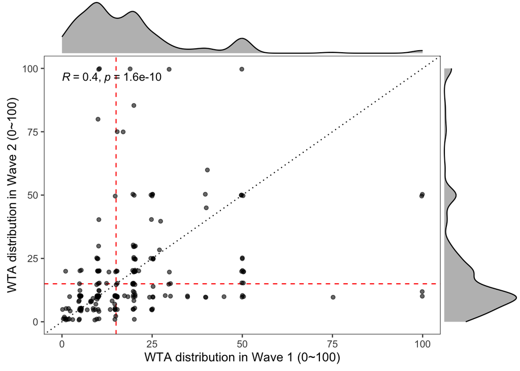

```r
library(tidyverse)
library(ggplot2)
library(DT)
library(haven)
library(ggpubr)
library(cowplot)
library(ggthemes)
library(readr)
library(ggExtra)
library(scales)
wta_df <- read_csv("wta/wta_df.csv", col_types = cols(userid = col_character(),
                                                      wta_w1 = col_integer(),
                                                      wta_w2 = col_integer(),
                                                      w2_compre1 = col_integer(),
                                                      w2_compre2 = col_integer()))


plot0 <- ggplot(wta_df, mapping = aes(wta_w1, wta_w2)) +
  geom_abline(intercept = 0, slope = 1, lty = 3, color = 'black') +
  geom_hline(yintercept = 15, lty = 2, color = 'red') +
  geom_vline(xintercept = 15, lty = 2, color = 'red') +
  geom_jitter(alpha=0.6) +
  stat_cor(method = 'pearson') +
  xlim(c(0, 100)) +
  ylim(c(0, 100)) +
  theme_few() +
  theme(legend.position = 'bottom') +
  xlab('WTA distribution in Wave 1 (0~100)') +
  ylab('WTA distribution in Wave 2 (0~100)')

ggMarginal(plot0, fill='gray')
```

## 4.2 Plot 2.

- Group by `category` based on WTA $
  - `always-under15`: user chose below $15 in both waves
  - `always-over15`: user chose $15 or over in both waves
  - `favorable-shift`: user chose $15 or over in wave 1 but shifted below $15 in wave 2
  - `unfavorable-shift`: user chose below $15 in wave 1 but shifted $15 or over in wave 2

Among those who got open-ended ver. in Wave 1,

- `always-over15`: 33 (28.4%)
- `always-under15`: 47 (40.5%)
- `favorable-shift`: 20 (17.2%)
- `unfavorable-shift`: 16 (13.8%)

cf) Among those who got scale ver. in Wave 1,

- `always-over15`: 53 (40.8%)
- `always-under15`: 35 (26.9%)
- `favorable-shift`: 32 (24.6%)
- `unfavorable-shift`: 10 (7.69%)

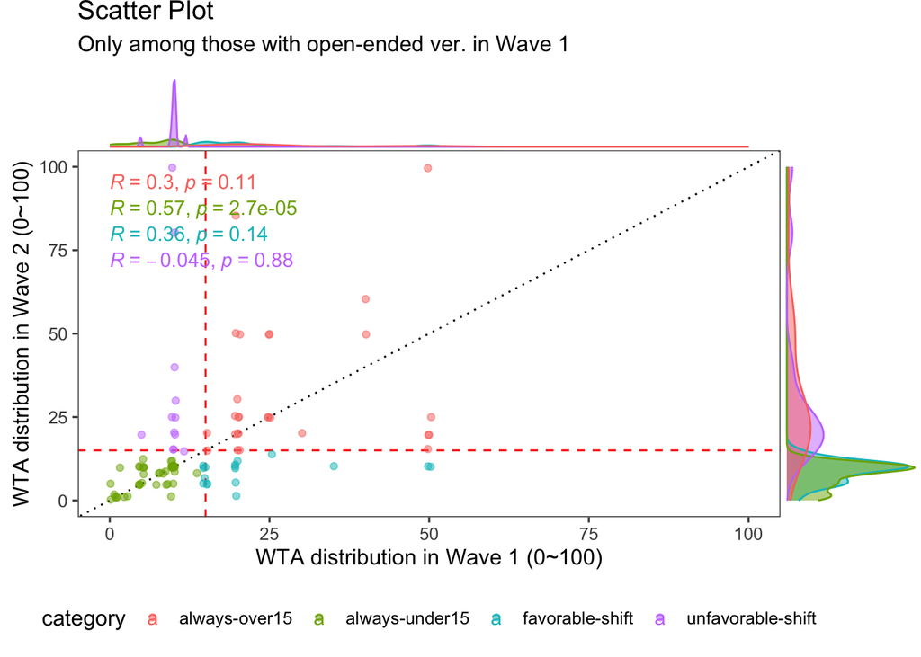

```r
wta_df |>
  filter(assigned_wta_w1=='open-ended') |>
    mutate(
    category = ifelse(
      wta_w1 < 15 & wta_w2 < 15, "always-under15",
      ifelse(wta_w1 >= 15 & wta_w2 >= 15, "always-over15",
             ifelse(wta_w1 >=15 & wta_w2 < 15, "favorable-shift", "unfavorable-shift")))
    ) |>
    filter(!is.na(wta_w1)) -> op_wta_df


plot1_op <- ggplot(op_wta_df, mapping = aes(wta_w1, wta_w2, color=category)) +
  geom_abline(intercept = 0, slope = 1, lty = 3, color = 'black') +
  geom_hline(yintercept = 15, lty = 2, color = 'red') +
  geom_vline(xintercept = 15, lty = 2, color = 'red') +
  geom_jitter(alpha=0.5) +
  stat_cor(method = 'pearson') +
  xlim(c(0, 100)) +
  ylim(c(0, 100)) +
  theme_few() +
  theme(legend.position = 'bottom') +
  xlab('WTA distribution in Wave 1 (0~100)') +
  ylab('WTA distribution in Wave 2 (0~100)') +
  ggtitle('Scatter Plot', subtitle = 'Only among those with open-ended ver. in Wave 1')


ggMarginal(plot1_op, groupColour = TRUE, groupFill = TRUE)
```